# FDM_blogpost

The simplest numerical approach to solving differential equations is probably the finite difference method. To explore this method, let's write a solver for an arbitrary linear ODE with Robin boundary conditions:

$$\frac{\partial y}{\partial t}=s(x,t)+a_0(x,t)y+a_1(x,t)\frac{\partial y}{\partial x}+a_2(x,t)\frac{\partial^2 y}{\partial x^2}+\cdots$$$$b_0(t)+b_1(t)y(x_L,t)+b_2\frac{\partial y}{\partial x}(x_L,t)=0$$$$c_0(t)+c_1(t)y(x_R,t)+c_2\frac{\partial y}{\partial x}(x_R,t)=0$$$$y(x,t_0)=f(x)$$

We begin the finite difference method with the decision to discretize our solution; rather than solving this equation at every point $x$, we'll choose a finite set of points $x_i$ and only worry about evaluating anything at these. To start, the initial condition lets us immediately calculate $y_i\equiv f(x_i)$. Now, in order to evolve the values of $y_i$ with time we also need to know the derivatives at all $x_i$. For this, we turn to Taylor series. We can express the Taylor series for the non-grid neighborhood around each point as $$y(x)\approx y_i+\frac{\partial y_i}{\partial x}\frac{x-x_i}{1!}+\frac{\partial^2 y_i}{\partial x^2}\frac{(x-x_i)^2}{2!}+\ldots$$ As long as we truncate at a high enough degree, a Taylor series centered on an adjacent point $y_{i-1}$ should give a good approximation for the value of $y_i$ (and vice versa). For demonstration purposes, let's truncate at the second order derivatives. If we assert that the Taylor series *exactly* matches the true values of adjacent grid points, then we can express this system as a matrix equation:

$$ \begin{bmatrix} 1 & x_{i-1}-x_i & \frac{(x_{i-1}-x_i)^2}{2}\\ 1 & 0 & 0\\ 1 & x_{i+1}-x_i & \frac{(x_{i+1}-x_i)^2}{2} \end{bmatrix} \begin{bmatrix} y_i\\ \frac{\partial y_i}{\partial x}\\ \frac{\partial^2 y_i}{\partial x^2} \end{bmatrix} = \begin{bmatrix} y_{i-1}\\ y_i\\ y_{i+1} \end{bmatrix} $$

Of course, we do not know the derivatives; we would like to solve for them! We do, however, know every value of the matrix (from the definition of Taylor series) and every value $y_i$. If we simply invert the matrix, we will have a list of formulae for the first and second derivatives at $x_i$ using only the known values $y_{i-1}$ through $y_{i+1}$. To make the result look a bit nicer, we define $x_{i-1}-x_i\equiv\Delta_L$ and $x_{i+1}-x_i\equiv\Delta_R$.

$$ \begin{bmatrix} y_i\\ \frac{\partial y_i}{\partial x}\\ \frac{\partial^2 y_i}{\partial x^2} \end{bmatrix} = \begin{bmatrix} 0 & 1 & 0\\ \frac{-\Delta_R}{\Delta_L(\Delta_L-\Delta_R)} & -\frac{\Delta_L+\Delta_R}{\Delta_L\Delta_R} & \frac{-\Delta_L}{\Delta_R(\Delta_R-\Delta_L)}\\ \frac{2}{\Delta_L(\Delta_L-\Delta_R)} & \frac{2}{\Delta_L\Delta_R} & \frac{2}{\Delta_R(\Delta_R-\Delta_L)} \end{bmatrix} \begin{bmatrix} y_{i-1}\\ y_i\\ y_{i+1} \end{bmatrix} $$

To use this, all we need to do is dot the vector of our $y_i$ values with each row. The top row trivially returns the identity of the point $y_i$, but the second and third rows yield formulae for the first and second derivative using only the value of the solution variable $y_i$!

Notably, we have assumed nothing about our grid this far. Let's choose some arbitrary values for the given problem, and take our points $x_i$ to be uniformly distributed between $x_L$ and $x_R$. Ignoring for a moment the edges where $x_{i-1}$ and $x_{i+1}$ do not exist (we'll look at edges next), we can solve this matrix as described above for the interior points.

```python
import numpy as np

x_L = 0 #Point of left robin BC
x_R = 1 #Point of right robin BC
N = 11 #Number of grid points to sample over region. 11 chosen so dx=0.1

x_i = np.linspace(x_L,x_R,N) #Uniformly sample x (including the boundary points)
i = 5 #Choose a random interior point, WLOG because of uniform distribution
A = np.zeros((3,3)) #Create a 3x3 matrix to populate with taylor series
A[0,:] = [(x_i[i-1]-x_i[i])**j/np.math.factorial(j) for j in range(3)] #Fill top row with Taylor series
A[1,:] = [1,0,0] #Middle row Taylor series
A[2,:] = [(x_i[i+1]-x_i[i])**j/np.math.factorial(j) for j in range(3)] #Fill top row with Taylor series

_A = np.linalg.inv(A) #Invert A to get formulae for derivatives
print(np.round(_A,12))
```

```
[[   0.    1.    0.]
 [  -5.    0.    5.]
 [ 100. -200.  100.]]
```

For the case of our uniform points with spacing $\Delta x=0.1$, we have recovered the perhaps familiar formulae for centered first and second derivatives: $$ \frac{\partial y}{\partial x}\approx \frac{y_{i+1}-y_{i-1}}{2\Delta x}=-5*y_{i-1}+0*y_i+5*y_{i+1} $$

$$ \frac{\partial^2 y}{\partial x^2}\approx \frac{y_{i-1}-2y_i+y_{i+1}}{\Delta x^2}=100*y_{i-1}-200*y_i+100*y_{i+1} $$

Because we went up to the second derivative in our initial derivation, this method is second order accurate. We could just as easily have gone to a higher order and gotten a more accurate equation for the derivatives; this method works to arbitrary order, as long as there are sufficiently many adjacent points. The last thing we need to figure out is how the edge points are handled. For this, we can simply give up on centering our matrix on the point of interest and instead use a different number of points to the left/right of our point $y_i$. For example, the matrix equation for 4th-order accurate derivatives on the leftmost point is written below, using the shorthand $x_j-x_i=\Delta_j$:

$$ \begin{bmatrix} 1&0&0&0&0\\ 1&\Delta_{i+1}&\Delta_{i+1}^2/2&\Delta_{i+1}^3/3!&\Delta_{i+1}^4/4!\\ 1&\Delta_{i+2}&\Delta_{i+2}^2/2&\Delta_{i+2}^3/3!&\Delta_{i+2}^4/4!\\ 1&\Delta_{i+3}&\Delta_{i+3}^2/2&\Delta_{i+3}^3/3!&\Delta_{i+3}^4/4!\\ 1&\Delta_{i+4}&\Delta_{i+4}^2/2&\Delta_{i+4}^3/3!&\Delta_{i+4}^4/4!\\ \end{bmatrix} \begin{bmatrix} y_i\\ \frac{\partial y_i}{\partial x}\\ \frac{\partial^2 y_i}{\partial x^2}\\ \frac{\partial^3 y_i}{\partial x^3}\\ \frac{\partial^4 y_i}{\partial x^4} \end{bmatrix} = \begin{bmatrix} y_i\\ y_{i+1}\\ y_{i+2}\\ y_{i+3}\\ y_{i+4} \end{bmatrix} $$

With this, we have everything we need to evaluate derivatives of arbitrary order anywhere on an arbitrarily discretized grid! Let's write a function which returns the inverted matrix, given the grid points, an index for the point of interest, and the desired order of accuracy.

```python
def D_matrix(X,i,max_order):
  """
  Parameters
  ----------
  X : np.ndarray
    Array of x points which make up the computational domain
  i : int
    index of point to center the Taylor series on
  max_order : even int
    maximum derivative order to truncate at

  Returns
  -------
  np.ndarray of size (max_order+1,max_order+1) where each row can be dotted with
  the neighborhood of points to give an approximate derivative
  """
  #In order for A to be invertible, we need it to be square. Since we have a row
  #for each order of derivative as well as the identity point y_i, the dimension
  #is 1 greater than the order.
  n = max_order+1
  A = np.zeros((max_order+1,max_order+1))
  #If width needed for equal neighbors exceeds bounds, use unequal number of neighbors by shifting left boundary
  if i<max_order//2: #Point is too far left for equal neighbors
    i_left = 0
  elif i>=len(X)-max_order//2: #Point is too far right for equal neighbors
    i_left = len(X)-max_order-1
  else: #Point sufficiently interior to use equal neighbors
    i_left = i-max_order//2
  for j in range(max_order+1):
    dx = X[i_left+j]-X[i]
    A[j] = [dx**k/np.math.factorial(k) for k in range(max_order+1)]
  return np.linalg.inv(A)
```

To use the matrix in code, we simply index the row corresponding to that derivative and take the dot product with the corresponding vector of $y_i$ values in the same neighborhood. Let's write a function to calculate the first derivative like this using second order Taylor series.

```python
#Calculate first derivative at each point with second order method
def D1(X,Y,i):
  """
  Returns the first derivative at X[i],Y[i] using 2nd order finite differences

  Parameters
  ----------
  X : np.ndarray
    Array of x points which make up the computational domain
  y : np.ndarray
    Array of y values corresponding to the x points
  i : int
    index of point to calculate derivative at

  Returns
  -------
  D : float
    First derivative of Y at X[i]
  """
  _A = D_matrix(X,i,2)
  if i<1: #Point is too far left for equal neighbors
    i_left = 0
  elif i>=len(X)-1: #Point is too far right for equal neighbors
    i_left = len(X)-3
  else: #Point sufficiently interior to use equal neighbors
    i_left = i-1
  #Take dot product of second row with the group of 3 y_i values
  return _A[1]@Y[i_left:i_left+3]
```

Finally, we can start to look at the accuracy of this approach by applying it to some functions with analytic derivatives and checking the error.

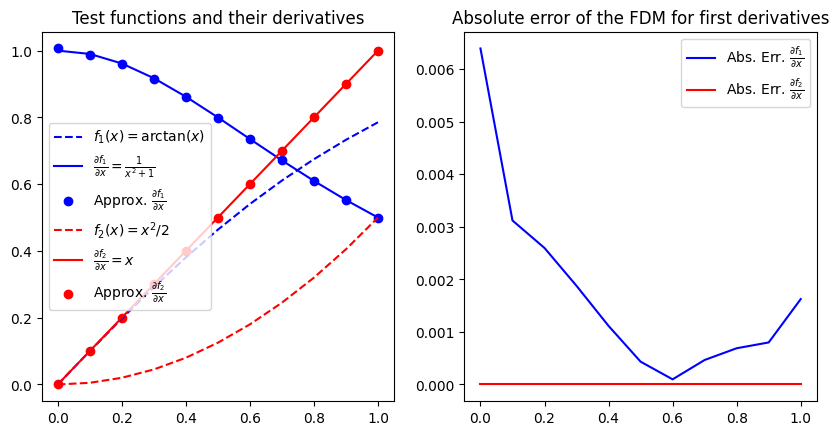

```python
import matplotlib.pyplot as plt

def f1(x):
  #f1(x)=arctan(x)
  return np.arctan(x)
def g1(x):
  #d/dx f1(x) = 1/(x^2+1)
  return 1/(x**2+1)

def f2(x):
  #y=x^2/2
  return x**2/2
def g2(x):
  #d/dx f2(x) = x
  return x

#Discretized function data
y1 = f1(x_i)
y2 = f2(x_i)
#Exact derivative values on discrete points
dy1 = g1(x_i)
dy2 = g2(x_i)

dy1_approx = [D1(x_i,y1,i) for i in range(len(y1))]
dy2_approx = [D1(x_i,y2,i) for i in range(len(y2))]

fig,(ax1,ax2) = plt.subplots(1,2)
fig.set_figwidth(10)
ax1.plot(x_i,y1,color="Blue",linestyle="--",label=r"$f_1(x)=\arctan(x)$")
ax1.plot(x_i,dy1,color="Blue",label=r"$\frac{\partial f_1}{\partial x}=\frac{1}{x^2+1}$")
ax1.scatter(x_i,dy1_approx,color="Blue",label=r"Approx. $\frac{\partial f_1}{\partial x}$")
ax1.plot(x_i,y2,color="Red",linestyle="--",label=r"$f_2(x)=x^2/2$")
ax1.plot(x_i,dy2,color="Red",label=r"$\frac{\partial f_2}{\partial x}=x$")
ax1.scatter(x_i,dy2_approx,color="Red",label=r"Approx. $\frac{\partial f_2}{\partial x}$")
ax1.legend()
ax1.set_title("Test functions and their derivatives")
ax2.plot(x_i,np.abs(dy1_approx-dy1),color="Blue",label=r"Abs. Err. $\frac{\partial f_1}{\partial x}$")
ax2.plot(x_i,np.abs(dy2_approx-dy2),color="Red",label=r"Abs. Err. $\frac{\partial f_2}{\partial x}$")
ax2.legend()
ax2.set_title("Absolute error of the FDM for first derivatives")
```

We can see that the method appears to be working. As one might expect, the accuracy is worst at the edges where we had to extend the Taylor series in only one direction away from the point of interest. Despite this, the absolute error is on the order of $\Delta x^2$ at all points as we should expect for a second order method. We should also not be surprised to see that this method recovers the exact derivative (to machine precision) for the quadratic function; the method is second order accurate, as is the function. We can also look at what happens when the grid is not uniform, since our model should naturally handle uneven spacing. Let's try to reduce the error around the edges by clustering points there, and make an identical plot to the one above with this new sample density.

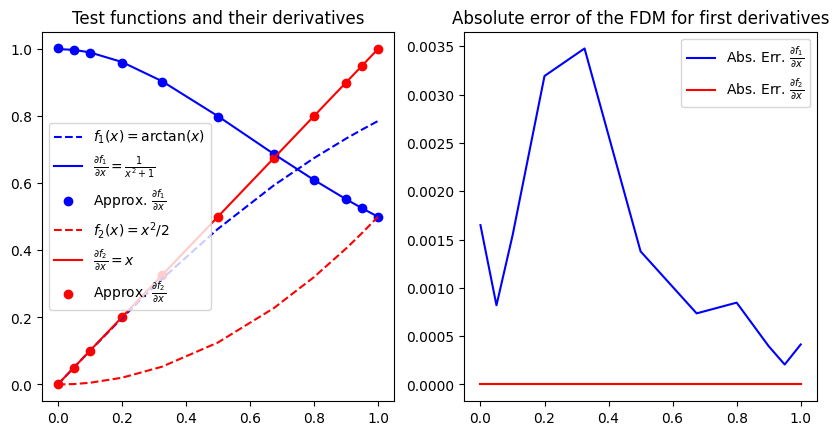

```python
x_i = np.array([0.0,0.05,0.1,0.2,0.325,0.5,0.675,0.8,0.90,0.95,1.0])
#Discretized function data
y1 = f1(x_i)
y2 = f2(x_i)
#Exact derivative values on discrete points
dy1 = g1(x_i)
dy2 = g2(x_i)

dy1_approx = [D1(x_i,y1,i) for i in range(len(y1))]
dy2_approx = [D1(x_i,y2,i) for i in range(len(y2))]

fig,(ax1,ax2) = plt.subplots(1,2)
fig.set_figwidth(10)
ax1.plot(x_i,y1,color="Blue",linestyle="--",label=r"$f_1(x)=\arctan(x)$")
ax1.plot(x_i,dy1,color="Blue",label=r"$\frac{\partial f_1}{\partial x}=\frac{1}{x^2+1}$")
ax1.scatter(x_i,dy1_approx,color="Blue",label=r"Approx. $\frac{\partial f_1}{\partial x}$")
ax1.plot(x_i,y2,color="Red",linestyle="--",label=r"$f_2(x)=x^2/2$")
ax1.plot(x_i,dy2,color="Red",label=r"$\frac{\partial f_2}{\partial x}=x$")
ax1.scatter(x_i,dy2_approx,color="Red",label=r"Approx. $\frac{\partial f_2}{\partial x}$")
ax1.legend()
ax1.set_title("Test functions and their derivatives")
ax2.plot(x_i,np.abs(dy1_approx-dy1),color="Blue",label=r"Abs. Err. $\frac{\partial f_1}{\partial x}$")
ax2.plot(x_i,np.abs(dy2_approx-dy2),color="Red",label=r"Abs. Err. $\frac{\partial f_2}{\partial x}$")
ax2.legend()
ax2.set_title("Absolute error of the FDM for first derivatives")
```

Look at that! We've nearly cut in half the peak absolute error in the approximation to the derivative of our first function, and the error is no longer concentrated at the edges where we need to apply the boundary conditions. With some confidence that we can evaluate the derivatives anywhere on our discretized grid, let's move on to evolving our solution variable $y$ with time now.

We start by again choosing a discretization, this time over the variable $t$.